# Titanic Survival Prediction

#### Author: Vincent Yeo

## Kaggle Competition

https://www.kaggle.com/c/titanic/data

### Background:

The sinking of the Titanic is one of the most infamous shipwrecks in history.

On April 15, 1912, during her maiden voyage, the widely considered “unsinkable” RMS Titanic sank after colliding with an iceberg. Unfortunately, there weren’t enough lifeboats for everyone onboard, resulting in the death of 1502 out of 2224 passengers and crew.

While there was some element of luck involved in surviving, it seems some groups of people were more likely to survive than others.

In this challenge, we ask you to build a predictive model that answers the question:

- “what sorts of people were more likely to survive?” using passenger data (ie name, age, gender, socio-economic class, etc).

#### Expected outputs:

- Predictions of survivals via binary classification
- Accuracy of the model in making the classification

```python
import os
import pandas as pd
import numpy as np
import matplotlib.pyplot as plt
import seaborn as sns
import warnings
warnings.filterwarnings('ignore')
```

```python
current_directory = os.getcwd()
train_dir = current_directory + "/data/train.csv"
test_dir = current_directory + "/data/test.csv"
```

### Exploratory Data Analysis

```python
train_set = pd.read_csv(train_dir)
test_set = pd.read_csv(test_dir)
```

```python
print("The number of passengers in train: " + str(len(train_set)))
print("The number of passengers in test: " + str(len(test_set)))
print("Total number of passengers: " + str(len(train_set) + len(test_set)))
```

```
The number of passengers in train: 891
The number of passengers in test: 418
Total number of passengers: 1309
```

```python
train_set.head()
```

|  | PassengerId | Survived | Pclass | Name | Sex | Age | SibSp | Parch | Ticket | Fare | Cabin | Embarked |
| --- | --- | --- | --- | --- | --- | --- | --- | --- | --- | --- | --- | --- |
| 0 | 1 | 0 | 3 | Braund, Mr. Owen Harris | male | 22.0 | 1 | 0 | A/5 21171 | 7.2500 | NaN | S |
| 1 | 2 | 1 | 1 | Cumings, Mrs. John Bradley (Florence Briggs Th... | female | 38.0 | 1 | 0 | PC 17599 | 71.2833 | C85 | C |
| 2 | 3 | 1 | 3 | Heikkinen, Miss. Laina | female | 26.0 | 0 | 0 | STON/O2. 3101282 | 7.9250 | NaN | S |
| 3 | 4 | 1 | 1 | Futrelle, Mrs. Jacques Heath (Lily May Peel) | female | 35.0 | 1 | 0 | 113803 | 53.1000 | C123 | S |
| 4 | 5 | 0 | 3 | Allen, Mr. William Henry | male | 35.0 | 0 | 0 | 373450 | 8.0500 | NaN | S |

```python
train_set.tail()
```

|  | PassengerId | Survived | Pclass | Name | Sex | Age | SibSp | Parch | Ticket | Fare | Cabin | Embarked |
| --- | --- | --- | --- | --- | --- | --- | --- | --- | --- | --- | --- | --- |
| 886 | 887 | 0 | 2 | Montvila, Rev. Juozas | male | 27.0 | 0 | 0 | 211536 | 13.00 | NaN | S |
| 887 | 888 | 1 | 1 | Graham, Miss. Margaret Edith | female | 19.0 | 0 | 0 | 112053 | 30.00 | B42 | S |
| 888 | 889 | 0 | 3 | Johnston, Miss. Catherine Helen "Carrie" | female | NaN | 1 | 2 | W./C. 6607 | 23.45 | NaN | S |
| 889 | 890 | 1 | 1 | Behr, Mr. Karl Howell | male | 26.0 | 0 | 0 | 111369 | 30.00 | C148 | C |
| 890 | 891 | 0 | 3 | Dooley, Mr. Patrick | male | 32.0 | 0 | 0 | 370376 | 7.75 | NaN | Q |

```python
train_set.info()
# Age, Cabin, Embarked has missing data
```

```
<class 'pandas.core.frame.DataFrame'>
RangeIndex: 891 entries, 0 to 890
Data columns (total 12 columns):
PassengerId    891 non-null int64
Survived       891 non-null int64
Pclass         891 non-null int64
Name           891 non-null object
Sex            891 non-null object
Age            714 non-null float64
SibSp          891 non-null int64
Parch          891 non-null int64
Ticket         891 non-null object
Fare           891 non-null float64
Cabin          204 non-null object
Embarked       889 non-null object
dtypes: float64(2), int64(5), object(5)
memory usage: 83.7+ KB
```

```python
# filter out all categorical variables and do unique count on them
for col in train_set.columns:
    print(train_set[col].value_counts())
    print("\n")

# PassengerId, Names are all unique and distinct
# There are 342 that survived and 549 that did not survived
# Majority of the passengers are in Class 3, while the least is in Class 2
# There is a majority of males in the train set
# Majority of passsengers have no siblings, parents or children on board
# There are 681 distinct ticket number in train set
# There are 147 distinct cabins in train set
# There are majority are embarking towards Southampton, while the least are going to Queenstown
```

```
891    1
293    1
304    1
303    1
302    1
      ..
591    1
590    1
589    1
588    1
1      1
Name: PassengerId, Length: 891, dtype: int64


0    549
1    342
Name: Survived, dtype: int64


3    491
1    216
2    184
Name: Pclass, dtype: int64


Svensson, Mr. Johan                                1
Patchett, Mr. George                               1
Carter, Mr. William Ernest                         1
Fleming, Miss. Margaret                            1
Pengelly, Mr. Frederick William                    1
                                                  ..
Crease, Mr. Ernest James                           1
Skoog, Mrs. William (Anna Bernhardina Karlsson)    1
Abbing, Mr. Anthony                                1
Montvila, Rev. Juozas                              1
McCarthy, Mr. Timothy J                            1
Name: Name, Length: 891, dtype: int64


male      577
```

[output cut: 69 more lines]

```
F33            3
C22 C26        3
              ..
D15            1
C54            1
B86            1
E17            1
D7             1
Name: Cabin, Length: 147, dtype: int64


S    644
C    168
Q     77
Name: Embarked, dtype: int64
```

```python
# To plot distribution for numerical data
train_set.describe()
# Age has a mean age of around 29 with variation of 14 years old
# the youngest passsenger is 0.42 which may be erroneous, and the oldest is 80 years old
# SibSP has min of 0 siblings and max is 8 siblings
# Parch has a min of 0 parents/children and max of 6 children
```

|  | PassengerId | Survived | Pclass | Age | SibSp | Parch | Fare |
| --- | --- | --- | --- | --- | --- | --- | --- |
| count | 891.000000 | 891.000000 | 891.000000 | 714.000000 | 891.000000 | 891.000000 | 891.000000 |
| mean | 446.000000 | 0.383838 | 2.308642 | 29.699118 | 0.523008 | 0.381594 | 32.204208 |
| std | 257.353842 | 0.486592 | 0.836071 | 14.526497 | 1.102743 | 0.806057 | 49.693429 |
| min | 1.000000 | 0.000000 | 1.000000 | 0.420000 | 0.000000 | 0.000000 | 0.000000 |
| 25% | 223.500000 | 0.000000 | 2.000000 | 20.125000 | 0.000000 | 0.000000 | 7.910400 |
| 50% | 446.000000 | 0.000000 | 3.000000 | 28.000000 | 0.000000 | 0.000000 | 14.454200 |
| 75% | 668.500000 | 1.000000 | 3.000000 | 38.000000 | 1.000000 | 0.000000 | 31.000000 |
| max | 891.000000 | 1.000000 | 3.000000 | 80.000000 | 8.000000 | 6.000000 | 512.329200 |

```python
print("Percentage of Survivors are {}% from the train set".format(round(train_set['Survived'].sum()/len(train_set) * 100, 2)))
```

```
Percentage of Survivors are 38.38% from the train set
```

```python
num_missing_values = train_set.isnull().sum().sort_values(ascending=False)
# print(num_missing_values)

percentage_missing = round(train_set.isnull().sum()/len(train_set)* 100, 1).sort_values(ascending=False)
# print(percentage_missing)

missing_data = pd.concat([num_missing_values, percentage_missing], axis=1, keys=['Num Missing', '%'])
missing_data.head(5)
```

|  | Num Missing | % |
| --- | --- | --- |
| Cabin | 687 | 77.1 |
| Age | 177 | 19.9 |
| Embarked | 2 | 0.2 |
| Fare | 0 | 0.0 |
| Ticket | 0 | 0.0 |

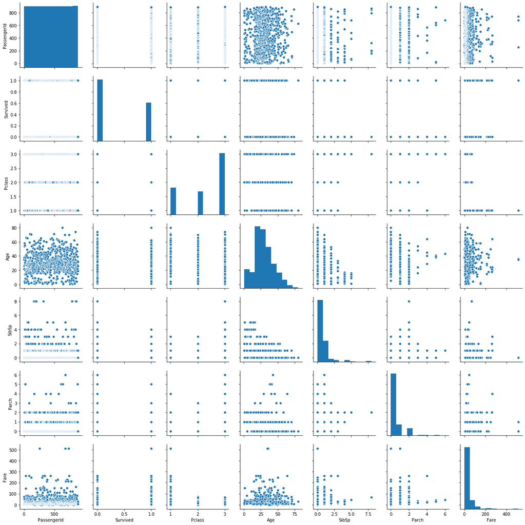

```python
sns.pairplot(train_set)
plt.show()
```

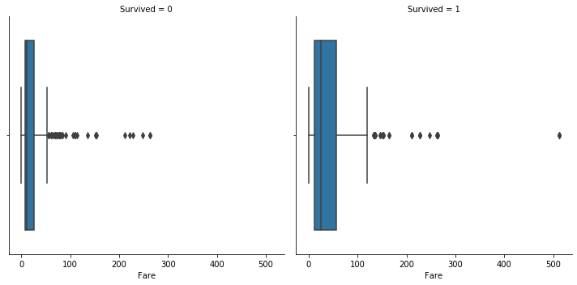

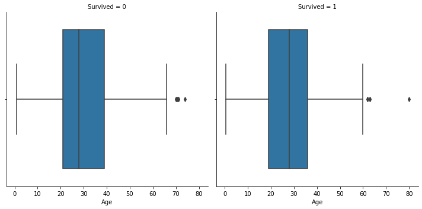

```python
sns.catplot(x="Fare", data=train_set, col="Survived", kind='box')
plt.show()
sns.catplot(x="Age", data=train_set, col="Survived", kind='box')
plt.show()
```

```python
#  Who is likely to survived?
#  Does Gender make a distinction between survival?
#  How would Age influence survival?
#  Those with lesser siblings, parents or children onboard? Or the opposite since they would care for those with family.
```

```python
def extractTitleFromName(df):
    df['Title'] = df.Name.apply(lambda name: name.split(',')[1].split('.')[0].strip())
    return df
```

```python
train_set = extractTitleFromName(train_set)
train_set['Title'].value_counts()
```

```
Mr              517
Miss            182
Mrs             125
Master           40
Dr                7
Rev               6
Col               2
Major             2
Mlle              2
Jonkheer          1
Don               1
Lady              1
Capt              1
Mme               1
Sir               1
Ms                1
the Countess      1
Name: Title, dtype: int64
```

```python
train_set.head()
```

|  | PassengerId | Survived | Pclass | Name | Sex | Age | SibSp | Parch | Ticket | Fare | Cabin | Embarked | Title |
| --- | --- | --- | --- | --- | --- | --- | --- | --- | --- | --- | --- | --- | --- |
| 0 | 1 | 0 | 3 | Braund, Mr. Owen Harris | male | 22.0 | 1 | 0 | A/5 21171 | 7.2500 | NaN | S | Mr |
| 1 | 2 | 1 | 1 | Cumings, Mrs. John Bradley (Florence Briggs Th... | female | 38.0 | 1 | 0 | PC 17599 | 71.2833 | C85 | C | Mrs |
| 2 | 3 | 1 | 3 | Heikkinen, Miss. Laina | female | 26.0 | 0 | 0 | STON/O2. 3101282 | 7.9250 | NaN | S | Miss |
| 3 | 4 | 1 | 1 | Futrelle, Mrs. Jacques Heath (Lily May Peel) | female | 35.0 | 1 | 0 | 113803 | 53.1000 | C123 | S | Mrs |
| 4 | 5 | 0 | 3 | Allen, Mr. William Henry | male | 35.0 | 0 | 0 | 373450 | 8.0500 | NaN | S | Mr |

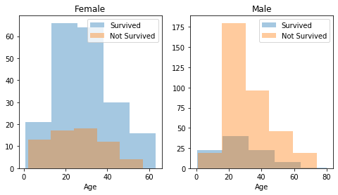

```python
fig, axes = plt.subplots(nrows=1, ncols=2, figsize=(8,4))
females = train_set.loc[train_set['Sex'] == 'female']
males = train_set.loc[train_set['Sex'] == 'male']

ax = sns.distplot(females[females['Survived'] == 1]['Age'].dropna(), bins=5, label = 'Survived', ax=axes[0], kde=False)
ax = sns.distplot(females[females['Survived'] == 0]['Age'].dropna(), bins=5, label = 'Not Survived', ax=axes[0], kde=False)
ax.legend()
ax.set_title('Female')

ax = sns.distplot(males[males['Survived'] == 1]['Age'].dropna(), bins=5, label = 'Survived', ax=axes[1], kde=False)
ax = sns.distplot(males[males['Survived'] == 0]['Age'].dropna(), bins=5, label = 'Not Survived', ax=axes[1], kde=False)
ax.legend()
_ = ax.set_title('Male')
```